# Midterm

STAT 471/571/701 Modern Data Mining

03/25/2019

**Name your submission using the scheme:**

`LastName_FirstName.pdf` etc.

**For example:** `Zhao_Linda` **.rmd**, **.pdf**, **.html** or **.docx**.

Instruction: This exam requires you to use R. It is completely open book/notes. Write your answers using .rmd format and knitr it into one of the html/pdf/docx format. **It looks like the easiest way is to knit it to a .html file!** Show your codes, plots or R-output when needed. If you have trouble formatting the plots, don’t worry about it. We are not looking for pretty solutions, rather to see if you are able to make sense out of data using R.

Data for Midterm: The data for midterm can be found at:

`/canvas/Files/Midterm/mortality_2012.csv` and `/canvas/Files/Midterm/breast-cancer.csv`.

Midterm Question File can be found at:

`/canvas/Files/Midterm/Miderm03_25_2019.Rmd`.

**Help:** As always skip any part you have trouble with and you may come back to finish it if you have time. Ask one of us for help if you are stuck somewhere for technical issues.

**Electronic Submission:** In the `Assignments` section, go to the `Midterm` assignment and upload your completed files: your `.rmd` file and a compiled file (either a pdf/html/docx). You can upload multiple files. The folder will be closed at **08:10PM**.

If you have trouble to upload your files, email them to `lzhao@wharton.upenn.edu` and `arunku@wharton.upenn.edu`.

**Answering the questions:** For all the questions whenever asked, you answer should show the R code first and then a description of the results to answer the questions. Do not print numbers without context from R code chunk.

**Example:** If you asked to report the mean of `mortality.rate`, then your answer should resemble

```r
# you need to put the dataset in the same folder where this .rmd file sits.
data <- read.csv("mortality_2012.csv")
cat("Mean of the mortality rate is:\n")
```

```
## Mean of the mortality rate is:
```

```r
mean(data$mortality.rate)
```

```
## [1] 31.72783
```

or

```r
mean(data$mortality.rate)
```

```
## [1] 31.72783
```

The mean of the mortality rate is 31.72783.

Do not just write

```r
mean(data$mortality.rate)
```

```
## [1] 31.72783
```

without any context or sentence answering the question.

## Part I: Mortality rate under age five

According to World Health Organization (WHO), 5.4 million children under age five died in 2017. The risk of a child dying before completing five years of age is still highest in Africa, 8 times compared to that in Europe. In addition, gaps of child mortality between high-income and low-income countries remain large. Reducing these inequalities across countries and saving more child lives by ending preventable child deaths are important priorities of WHO.

In this exam, we will look into the mortality rate of children under age five of 115 countries around the world in 2012. The goal is to identify important factors associated with children mortality rate and to be able to quantify the relationship.

The data is obtained from DataBank of the World Bank. https://databank.worldbank.org/data/home.aspx. The following R-chunk reads the data `mortality_2012.csv`.

```r
# you need to put the dataset in the same folder where this .rmd file sits.
data <- read.csv("mortality_2012.csv")
```

| Variable | Description |
| --- | --- |
| mortality.rate | Mortality rate, under-5 (per 1,000 live births) |
| Country | Country name |
| adolescent.fertility.rate | Adolescent fertility rate (births per 1,000 women ages 15-19) |
| agri.forestry.fish.gdp.pct | Agriculture, forestry, and fishing, value added (% of GDP) |
| industry.gdp.pct | Industry (including construction), value added (% of GDP) |
| CO2 | CO2 emissions (metric tons per capita) |
| fertility.rate | Fertility rate, total (births per woman) |
| GDP | GDP (current US$) |
| GDP.per.capita | GDP per capita (current US$) |
| gdp.grwoth.rate | GDP growth (annual %) |
| gni | GNI, PPP (current international $) |
| inflation | Inflation, GDP deflator (annual %) |
| LE | Life expectancy at birth, total (years) |
| population.growth | Population growth (annual %) |
| population | Population, total |
| unemployment | Unemployment, total (% of total labor force)) |
| Continent | Continent |
| Urban.pop | Percentage of urban population |
| Household.consump | Household consumption expenditure in million |
| Forest.area | Percentage of forest |
| Water | Access to improved water source in percentage |
| Food.prod.index | Food production index |
| Arable.land | Arable land per capita |
| Health.expend | Health expenditure percentage of GDP |
| Immunization | DPT Immunization percentage of children |
| Sanitation.faci | Access to improved sanitation facilities in percentage |
| Immunization.measles | Measles Immunization percentage of children |
| Health.exp.pocket | Percentage of out of pocket health expenditure to total health |
| Fixed.tel | Fixed telephone subscriptions per 100 people |
| Mobile.cel | Mobile cellular subscriptions per 100 people |
| Internet.users | Internet users per 100 people |

## Question 1: EDA of `data`

### a) Quick Summary

```r
summary(data)
```

```
##        Country    mortality.rate   adolescent.fertility.rate
##  Algeria   :  1   Min.   :  2.50   Min.   :  3.503
##  Argentina :  1   1st Qu.:  5.50   1st Qu.: 13.239
##  Armenia   :  1   Median : 16.80   Median : 36.061
##  Australia :  1   Mean   : 31.73   Mean   : 49.573
##  Austria   :  1   3rd Qu.: 44.80   3rd Qu.: 75.420
##  Azerbaijan:  1   Max.   :142.90   Max.   :202.109
##  (Other)   :109
##  agri.forestry.fish.gdp.pct industry.gdp.pct      CO2
##  Min.   : 0.3593            Min.   : 3.326   Min.   : 0.0303
##  1st Qu.: 2.8998            1st Qu.:20.907   1st Qu.: 0.8737
##  Median : 6.7252            Median :25.634   Median : 3.1593
##  Mean   :11.0971            Mean   :27.443   Mean   : 4.4039
##  3rd Qu.:16.4159            3rd Qu.:31.943   3rd Qu.: 6.5820
##  Max.   :54.8998            Max.   :74.768   Max.   :20.0842
##
##  fertility.rate       GDP            GDP.per.capita     GDP.grwoth.rate
##  Min.   :1.269   Min.   :1.564e+09   Min.   :   250.4   Min.   :-7.4446
##  1st Qu.:1.667   1st Qu.:1.448e+10   1st Qu.:  1676.2   1st Qu.: 0.5068
##  Median :2.236   Median :5.655e+10   Median :  6337.9   Median : 3.6423
##  Mean   :2.721   Mean   :5.681e+11   Mean   : 14859.4   Mean   : 3.2154
##  3rd Qu.:3.209   3rd Qu.:3.208e+11   3rd Qu.: 16354.6   3rd Qu.: 5.4339
##  Max.   :7.420   Max.   :1.616e+13   Max.   :106749.0   Max.   :12.3198
##
##       GNI              inflation      population.growth
##  Min.   :2.503e+09   Min.   :-1.170   Min.   :-1.3412
##  1st Qu.:2.983e+10   1st Qu.: 1.776   1st Qu.: 0.3732
##  Median :1.142e+11   Median : 3.580   Median : 1.2670
##  Mean   :1.379e+12   Mean   : 5.646   Mean   : 1.3495
##  3rd Qu.:4.769e+11   3rd Qu.: 6.604   3rd Qu.: 2.1814
##  Max.   :7.215e+13   Max.   :75.277   Max.   : 6.9053
##
##    population         unemployment            Continent    Urban.pop
##  Min.   :3.207e+05   Min.   : 0.160   Africa       :31   Min.   :11.19
##  1st Qu.:4.967e+06   1st Qu.: 3.875   Asia         :28   1st Qu.:42.73
##  Median :1.089e+07   Median : 6.790   Europe       :35   Median :62.39
##  Mean   :5.169e+07   Mean   : 8.146   North America:11   Mean   :58.93
##  3rd Qu.:3.466e+07   3rd Qu.:10.985   Oceania      : 1   3rd Qu.:75.08
##  Max.   :1.351e+09   Max.   :24.790   South America: 9   Max.   :97.73
##
```

[output cut: 17 more lines]

```
##  Min.   :49.00        Min.   : 5.30     Min.   : 0.00   Min.   : 14.92
##  1st Qu.:87.00        1st Qu.:18.70     1st Qu.: 4.42   1st Qu.: 82.43
##  Median :93.00        Median :31.64     Median :15.57   Median :108.05
##  Mean   :89.99        Mean   :32.92     Mean   :19.37   Mean   :104.48
##  3rd Qu.:97.00        3rd Qu.:45.80     3rd Qu.:29.57   3rd Qu.:127.07
##  Max.   :99.00        Max.   :74.46     Max.   :62.11   Max.   :187.36
##
##  Internet.users
##  Min.   : 1.22
##  1st Qu.:13.72
##  Median :39.75
##  Mean   :41.04
##  3rd Qu.:62.12
##  Max.   :96.21
##
```

Report the following information about `data`:

**i)** How many variables and observations does `data` have?

```r
dim(data)
```

```
## [1] 115  30
```

There are 115 observations and 30 variables

**ii)** Are there any missing values?

```r
sum(is.na(data))
```

```
## [1] 0
```

No, there is no missing value in the dataset.

### b) `mortality.rate` in 2012

**i)** Which country has the highest `mortality.rate`? And which country has the lowest `mortality.rate`? What are the mean and median `mortality.rate` among all countries in data?

```r
data %>% group_by(Country) %>% dplyr::select(mortality.rate) %>% arrange(mortality.rate)
```

```
## # A tibble: 115 x 2
## # Groups:   Country [115]
##    Country        mortality.rate
##    <fct>                   <dbl>
##  1 Iceland                   2.5
##  2 Finland                   2.8
##  3 Luxembourg                2.8
##  4 Slovenia                  2.9
##  5 Japan                     3
##  6 Norway                    3
##  7 Sweden                    3
##  8 Czech Republic            3.2
##  9 Cyprus                    3.3
## 10 Spain                     3.6
## # ... with 105 more rows
```

Central African Republic has the highest mortality rate and Iceland has the lowest

```r
mean(data[,"mortality.rate"])
```

```
## [1] 31.72783
```

```r
median(data[,"mortality.rate"])
```

```
## [1] 16.8
```

The mean mortality rate is 31.73 and the median is 16.8

**ii)** Make a histogram of the `mortality.rate`. Use no more than three sentences to describe the distribution of the `mortality.rate`. (Does it look normal? Are there more countries with low `mortality.rate` or more countries with high `mortality.rate`?)

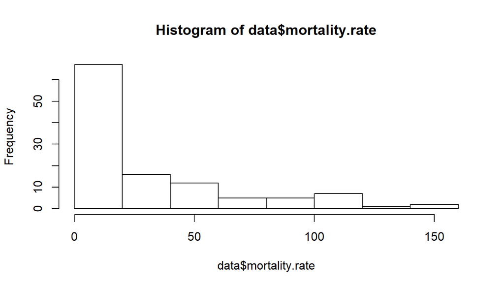

```r
hist(data$mortality.rate)
```

The histogram is not normal, it has a long tail to the right. From the histogram, we see there is a high frequency of fortality below than 25, so there are more countries with low mortality rate

**iii)** Report the mean and median `mortality.rate` by `Continent`. Which `Continent` has the highest mean `mortality.rate` and what is the value?

```r
data %>% group_by(Continent) %>% summarize(mean_mortality= mean(mortality.rate)) %>% arrange(mean_mortality)
```

```
## # A tibble: 6 x 2
##   Continent     mean_mortality
##   <fct>                  <dbl>
## 1 Oceania                 4.3
## 2 Europe                  5.36
## 3 North America          18.1
## 4 South America          21.6
## 5 Asia                   25.9
## 6 Africa                 75.4
```

Africa has the highest mortality rate (75.38)

**iv)** Show the boxplots of `mortality.rate` versus `Continent`. Write a brief summary based on these boxplots. No more than three sentences please.

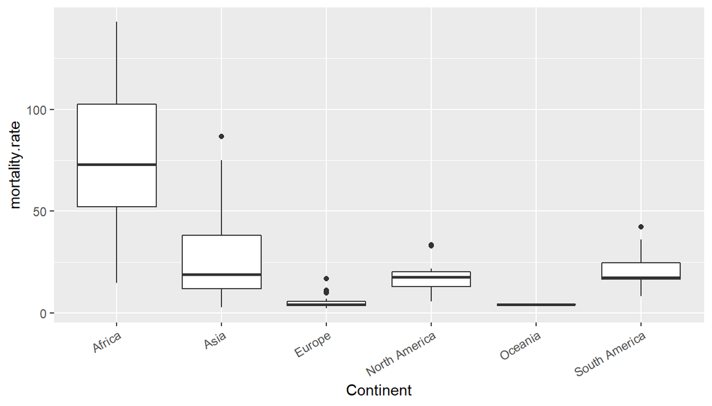

```r
data %>% ggplot(aes(x = Continent, y = mortality.rate)) +
  geom_boxplot() +
  theme(axis.text.x = element_text(angle = 30, hjust = 1))
```

From the box plot, we can see Africa and Asia have relatively high mortality rate and Africa has a longer range of mortality rate. Oceania and Europe has the lowest mortality rate.

## Question 2: Relation between mortality.rate and other variables

### a) Single most usueful factor

```r
cor.mat <- data %>% select(-Country, -Continent) %>% cor
cor.mat[1,]
```

```
##             mortality.rate  adolescent.fertility.rate
##                1.000000000                0.826333224
## agri.forestry.fish.gdp.pct           industry.gdp.pct
##                0.811744183               -0.105831654
##                        CO2             fertility.rate
##               -0.578322767                0.905627614
##                        GDP             GDP.per.capita
##               -0.188500283               -0.483895183
##            GDP.grwoth.rate                        GNI
##                0.469894159               -0.118341374
##                  inflation          population.growth
##                0.071930261                0.491870293
##                 population               unemployment
##               -0.006172731               -0.166284326
##                  Urban.pop          Household.consump
##               -0.675863608               -0.507710451
##                Forest.area                Arable.land
##               -0.124441650               -0.011832658
##                      Water            Food.prod.index
##               -0.803717025                0.479603735
##              Health.expend               Immunization
##               -0.490577957               -0.729817153
##            Sanitation.faci       Immunization.measles
##               -0.887278300               -0.731229148
##          Health.exp.pocket                  Fixed.tel
##                0.406867337               -0.692452102
##                 Mobile.cel             Internet.users
##               -0.641432817               -0.777111982
```

**i)** What does `cor.mat` contain? And what does `cor.mat[1,]` show?

cor() isused to compute a correlation matrix, cor.mat[1,] Showes row names ( mortality.rate for the correlation test)

**ii)** Based on the above correlation matrix, which single continuous variable will have the highest $R^2$ if we fit `mortality.rate` vs one variable at a time and why? **We only take the answer based on the above R-chunk! No need to do all the simple linear regressions.**

fertility.rate because it has the highest absolute correlation

### b) `mortality.rate` vs. `GDP`

**i)** Fit a linear model of `mortality.rate` vs. GDP. Make a scatter plot of GDP vs. `mortality.rate`, together with the regression line overlayed. Report the lm summary statistics. Is GDP a significant variable at .01 level?

```r
fit1 <- lm(mortality.rate~GDP, data)
summary(fit1)
```

```
##
## Call:
## lm(formula = mortality.rate ~ GDP, data = data)
##
## Residuals:
##    Min     1Q Median     3Q    Max
## -31.21 -25.26 -15.03  13.53 109.15
##
## Coefficients:
##               Estimate Std. Error t value Pr(>|t|)
## (Intercept)  3.376e+01  3.365e+00   10.03   <2e-16 ***
## GDP         -3.573e-12  1.751e-12   -2.04   0.0436 *
## ---
## Signif. codes:  0 '***' 0.001 '**' 0.01 '*' 0.05 '.' 0.1 ' ' 1
##
## Residual standard error: 34.47 on 113 degrees of freedom
## Multiple R-squared:  0.03553,    Adjusted R-squared:  0.027
## F-statistic: 4.163 on 1 and 113 DF,  p-value: 0.04365
```

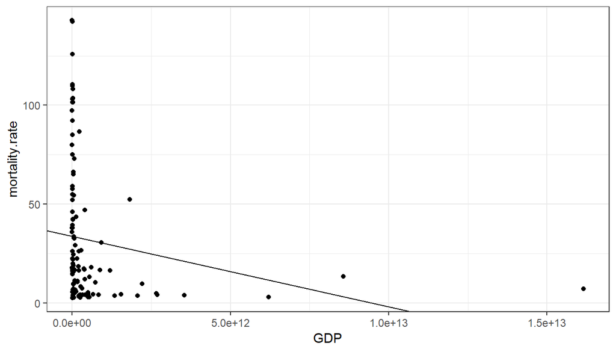

```r
data %>%
    ggplot(aes(x = GDP, y= mortality.rate)) + geom_point() +
    geom_abline(slope = -3.573e-12, intercept = 3.376e+01) +
    xlab("GDP") + ylab("mortality.rate") +
    theme_bw()
```

**ii)** Fit a linear model of `mortality.rate` vs. log(GDP). Here we use natural log. Make another scatter plot of log(GDP) vs. `mortality.rate` together with the regression liner. Report the lm summary statistics. Is the GDP in log scale significant at .01 level?

```r
fit1.1 <- lm(mortality.rate~log(GDP), data)
summary(fit1.1)
```

```
##
## Call:
## lm(formula = mortality.rate ~ log(GDP), data = data)
##
## Residuals:
##     Min      1Q  Median      3Q     Max
## -52.449 -20.913  -4.605  10.785  94.151
##
## Coefficients:
##             Estimate Std. Error t value Pr(>|t|)
## (Intercept)  257.941     34.940   7.382 2.84e-11 ***
## log(GDP)      -9.032      1.391  -6.495 2.31e-09 ***
## ---
## Signif. codes:  0 '***' 0.001 '**' 0.01 '*' 0.05 '.' 0.1 ' ' 1
##
## Residual standard error: 29.95 on 113 degrees of freedom
## Multiple R-squared:  0.2718, Adjusted R-squared:  0.2654
## F-statistic: 42.19 on 1 and 113 DF,  p-value: 2.308e-09
```

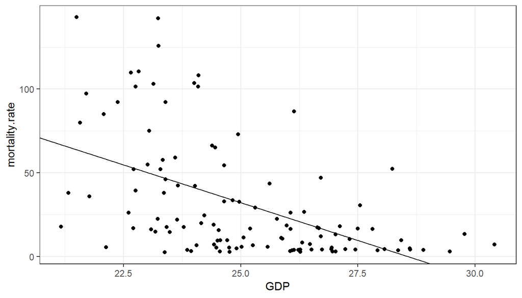

```r
data %>%
    ggplot(aes(x = log(GDP), y= mortality.rate)) + geom_point() +
    geom_abline(slope = -9.032  , intercept = 257.941) +
    xlab("GDP") + ylab("mortality.rate") +
    theme_bw()
```

**iii)** Which is a better model choice? And why? No more than three sentences.

The mortality.rate vs. log(GDP) is better. The scatter plot of mortality.rate vs. GDP shows the relationship between the two is clearly nonlinear

**iv)** Use your model in **ii)** regardless your answer in **iii)** and write your findings briefly (no more than 3 lines) summarizing the relationship between GDP and `mortality.rate`.

For a single unit change in log(GDP), on average, mortality.rate goes down by 9.032, assuming all other factors are held constant (but there are no others in this model).

### c) Relation between mortality.rate and other variables.

Now examine the relationship between mortality.rate vs Sanitation.faci, log(GDP) and Continent.

**i)** Fit a model of `mortality.rate` vs. Log(GDP), Sanitation.faci and Continent. Report the summary.

```r
fit2 <- lm(mortality.rate~log(GDP)+Sanitation.faci+Continent, data)
summary(fit2)
```

```
##
## Call:
## lm(formula = mortality.rate ~ log(GDP) + Sanitation.faci + Continent,
##     data = data)
##
## Residuals:
##     Min      1Q  Median      3Q     Max
## -41.705  -7.486  -0.411   5.359  51.632
##
## Coefficients:
##                         Estimate Std. Error t value Pr(>|t|)
## (Intercept)            139.44817   19.30426   7.224 7.79e-11 ***
## log(GDP)                -1.46666    0.83345  -1.760 0.081309 .
## Sanitation.faci         -0.77443    0.08033  -9.640 3.33e-16 ***
## ContinentAsia          -15.38648    5.10206  -3.016 0.003202 **
## ContinentEurope        -22.32766    5.85001  -3.817 0.000227 ***
## ContinentNorth America -20.44936    6.39035  -3.200 0.001809 **
## ContinentOceania       -16.54344   16.38432  -1.010 0.314911
## ContinentSouth America -16.86861    6.73657  -2.504 0.013788 *
## ---
## Signif. codes:  0 '***' 0.001 '**' 0.01 '*' 0.05 '.' 0.1 ' ' 1
##
## Residual standard error: 15.24 on 107 degrees of freedom
## Multiple R-squared:  0.8214, Adjusted R-squared:  0.8097
## F-statistic: 70.31 on 7 and 107 DF,  p-value: < 2.2e-16
```

log(GDP) and Sanitation.faci have negative effects on mortality rate. Among all the continnent, Afira has the highest effect

**ii)** Is log(GDP) a significant variable at .01 level after controlling for `Sanitation.faci` and `Continent`?

```r
Anova(fit2)
```

```
## Anova Table (Type II tests)
##
## Response: mortality.rate
##                  Sum Sq  Df F value    Pr(>F)
## log(GDP)          719.4   1  3.0967   0.08131 .
## Sanitation.faci 21590.5   1 92.9325 3.333e-16 ***
## Continent        3681.4   5  3.1692   0.01044 *
## Residuals       24858.7 107
## ---
## Signif. codes:  0 '***' 0.001 '**' 0.01 '*' 0.05 '.' 0.1 ' ' 1
```

The p-value for log(GDP) is 0.08131, which is higher than 0.01. It is not significant at 0.01 level.

**iii)** Are the means of mortality.rate among all Continents the same at .05 level after controlling for log(GDP) and `Sanitation.faci`?

No, the means of mortality.rate will be different among all continents.

**iv)** Based on this model fit, which Continent appears to have the highest mortality.rate after controlling for log(GDP) and `Sanitation.faci`? (No test needed.)

Africa

## Question 3: Linear Model building

In this question, we build a model for `mortality.rate` based on the covariates available in data. Your professor insists on that GDP should have been taken a log scale. So from now on you may drop GDP from the working data but keep log(GDP) there to avoid any potential issues. Call this extracted data as `data1`. (Show your code for this.)

### a) LASSO Regression: fit.lasso.0

**i)** Country names should not be a predictor. Explain why not? (one sentence only)

We cannot include Country because the data does not vary at the country level and as a result, a model with country would have no degrees of freedom to estimate anything.

**ii)** LASSO Regression: Use `cv.glmnet()` function on the data for the response `mortality.rate` on the covariates available. **Use the settings set.seed(471) and nfolds = 10.** (name this `fit.lasso.0`).

```r
data$log_gdp <- log(data$GDP)
data <- data %>% dplyr::select(-GDP)
data_sub <- data %>% dplyr::select(-Country)
```

```r
X <- model.matrix(mortality.rate ~. , data_sub)[, -1]
Y <- data$mortality.rate
```

```r
set.seed(471)
fit.lasso.0 <- cv.glmnet(X,Y,alpha=1,nfold=10)
```

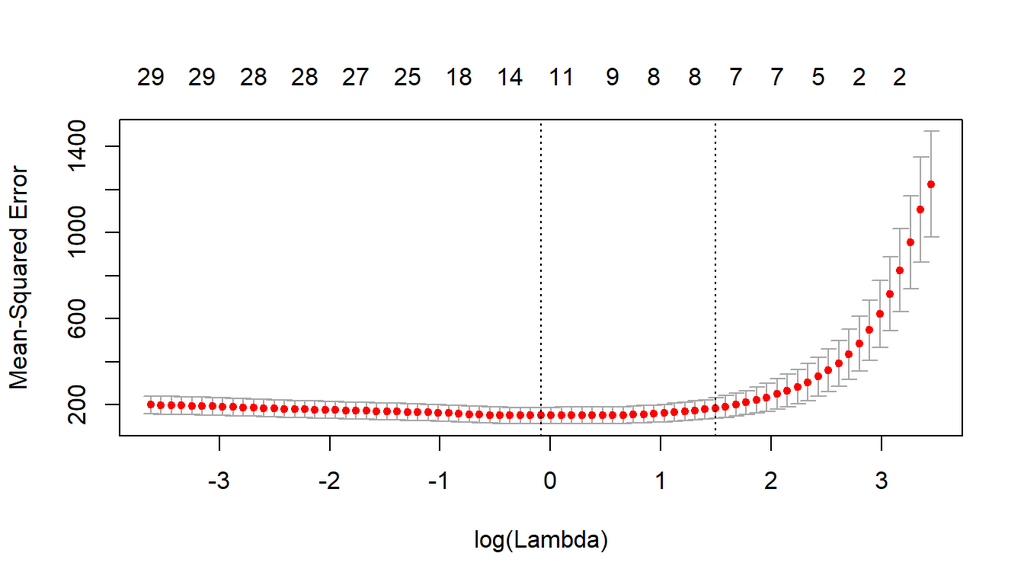

```r
plot(fit.lasso.0)
```

**iii)** What is the `lambda.1se` value and what are the covariates in the `lambda = lambda.1se` model?

```r
fit.lasso.0$lambda.1se
```

```
## [1] 4.466195
```

```r
coef.1se <- coef(fit.lasso.0, s="lambda.1se")
coef.1se <- coef.1se[which(coef.1se != 0),]
coef.1se
```

```
##                (Intercept)  adolescent.fertility.rate
##                72.24978747                 0.01281052
## agri.forestry.fish.gdp.pct             fertility.rate
##                 0.24144175                 9.52297090
##               Immunization            Sanitation.faci
##                -0.18440515                -0.27425851
##       Immunization.measles             Internet.users
##                -0.34044539                -0.05372153
```

lambda.1se = 4.466195 non-zero varables: `adolescent.fertility.rate`, `agri.forestry.fish.gdp.pct`, `fertility.rate`, `Immunization`, `Sanitation.faci`, `Immunization.measles`, `Internet.users`